# MP1

Emma Laslo, Jonah Kotzen, Marc Godec

2024-01-31

# Introduction

This project aims to dissect the nuances of pendulum-type walking speeds, pelvic tilt variations, and their correlations with human size and sex. Through data tracking and analysis, this report investigates the theoretical models and actual walking speeds, explores the biomechanical aspects of gait adaptations, and examines how these elements relate to the physical dimensions of the individual. The following sections explore the methodology, analysis, and interpretations of our findings, contributing to the broader understanding of human locomotion.

# Graphing Data

## Three Subjects (Emma, Jonah, Marc) at Fast and Slow Walking Speeds

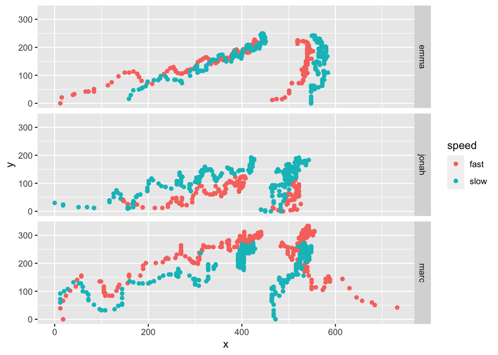

```r
walk.dat2 <- walk.dat %>%
  select(TID, PID, x, y, subject, speed) %>%
  filter(TID != 3) %>%
  group_by(speed, subject) %>%
  mutate(y = abs(y - max(y)))  # Note: Adjust this if you need a different transformation

walk.dat2 %>%
  ggplot(aes(x, y, color = speed)) +
  geom_point() +
  facet_grid(subject ~ .)
```

# Manipulating Data

## Correlating TIDs to Regions

```r
walk.dat2 <- walk.dat2%>%
  mutate(TID=replace(TID, TID==1, "hipR"))%>%
  mutate(TID=replace(TID, TID==2, "hipC"))%>%
  mutate(TID=replace(TID, TID==3, "legR"))
head(walk.dat2)
```

```
## # A tibble: 6 × 6
## # Groups:   speed, subject [1]
##   TID     PID     x     y subject speed
##   <chr> <dbl> <dbl> <dbl> <chr>   <chr>
## 1 hipR      1   519   225 emma    fast
## 2 hipR      2   519   222 emma    fast
## 3 hipR      3   519   222 emma    fast
## 4 hipR      4   519   222 emma    fast
## 5 hipR      5   519   222 emma    fast
## 6 hipR      6   519   222 emma    fast
```

## Pivoting Wider

```r
walk.wide <- walk.dat2%>%
  pivot_wider(names_from=TID,values_from=c("x","y"))
head(walk.wide)
```

```
## # A tibble: 6 × 7
## # Groups:   speed, subject [1]
##     PID subject speed x_hipR x_hipC y_hipR y_hipC
##   <dbl> <chr>   <chr>  <dbl>  <dbl>  <dbl>  <dbl>
## 1     1 emma    fast     519   429.    225   215.
## 2     2 emma    fast     519   429.    222   223.
## 3     3 emma    fast     519   429.    222   223.
## 4     4 emma    fast     519   427.    222   227.
## 5     5 emma    fast     519   427.    222   227.
## 6     6 emma    fast     519   427.    222   227.
```

## Calculating Pelvic Tilt (Theta)

```r
# Assuming walk.wide is our data frame after using pivot_wider()
walk.wide <- walk.dat2 %>%
  pivot_wider(names_from = TID, values_from = c("x", "y"))
# Calculating the angle theta
walk.wide <- walk.wide %>%
  mutate(
    dx = x_hipR - x_hipC,  # Change in x-coordinate
    dy = y_hipR - y_hipC,  # Change in y-coordinate
    theta = atan2(dy, dx) * (180 / pi)  # Calculate the angle in degrees
  )
# Viewing the first few rows of the data with theta
head(walk.wide)
```

```
## # A tibble: 6 × 10
## # Groups:   speed, subject [1]
##     PID subject speed x_hipR x_hipC y_hipR y_hipC    dx     dy  theta
##   <dbl> <chr>   <chr>  <dbl>  <dbl>  <dbl>  <dbl> <dbl>  <dbl>  <dbl>
## 1     1 emma    fast     519   429.    225   215.  90.3 10.3    6.53
## 2     2 emma    fast     519   429.    222   223.  90.3 -0.667 -0.423
## 3     3 emma    fast     519   429.    222   223.  90.3 -0.667 -0.423
## 4     4 emma    fast     519   427.    222   227.  91.7 -4.67  -2.91
## 5     5 emma    fast     519   427.    222   227.  91.7 -4.67  -2.91
## 6     6 emma    fast     519   427.    222   227.  91.7 -4.67  -2.91
```

## Calculating Mean Max Tilt

```r
# Calculate the maximum pelvic tilt angle for each subject and each speed
max_tilt_per_subject_speed <- walk.wide %>%
  group_by(subject, speed) %>%
  summarize(max_tilt = max(theta, na.rm = TRUE))
# Calculate the mean of the maximum tilt angles for each subject and each speed
mean_max_tilt_per_subject <- max_tilt_per_subject_speed %>%
  group_by(subject, speed) %>%
  summarize(mean_max_tilt = mean(max_tilt, na.rm = TRUE))
# Viewing the result
print(mean_max_tilt_per_subject)
```

```
## # A tibble: 6 × 3
## # Groups:   subject [3]
##   subject speed mean_max_tilt
##   <chr>   <chr>         <dbl>
## 1 emma    fast         13.2
## 2 emma    slow          0.909
## 3 jonah   fast         18.4
## 4 jonah   slow          9.27
## 5 marc    fast         19.9
## 6 marc    slow         23.0
```

## Graphing Max Tilt Between Speeds

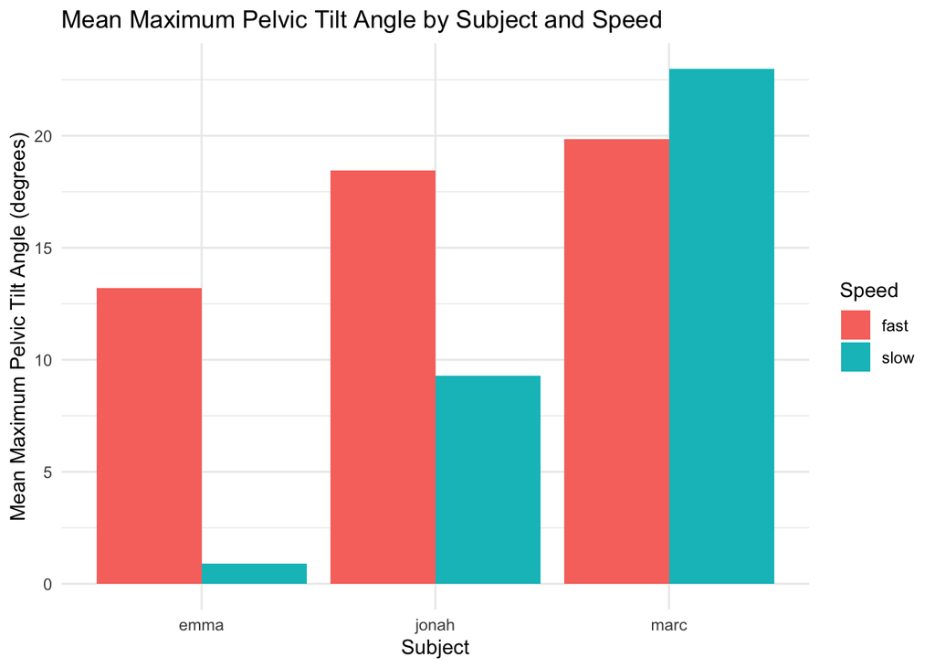

```r
ggplot(mean_max_tilt_per_subject, aes(x = subject, y = mean_max_tilt, fill = speed)) +
  geom_bar(stat = "identity", position = position_dodge()) +
  labs(title = "Mean Maximum Pelvic Tilt Angle by Subject and Speed",
       x = "Subject",
       y = "Mean Maximum Pelvic Tilt Angle (degrees)",
       fill = "Speed") +
  theme_minimal()
```

# Areas to Address (Class Data Included)

## Reading in Class Data

```r
class_data <- read.csv('class_gait_data.csv')

# Clean the 'sex' variable and remove NAs
class_data <- class_data %>%
  mutate(sex = as.factor(trimws(sex))) %>%
  filter(!is.na(sex))

# Check unique values again
unique(class_data$sex)
```

```
## [1] Female Male
## Levels:  Female Male
```

## Comparison of Theoretical and Actual Walking Speeds:

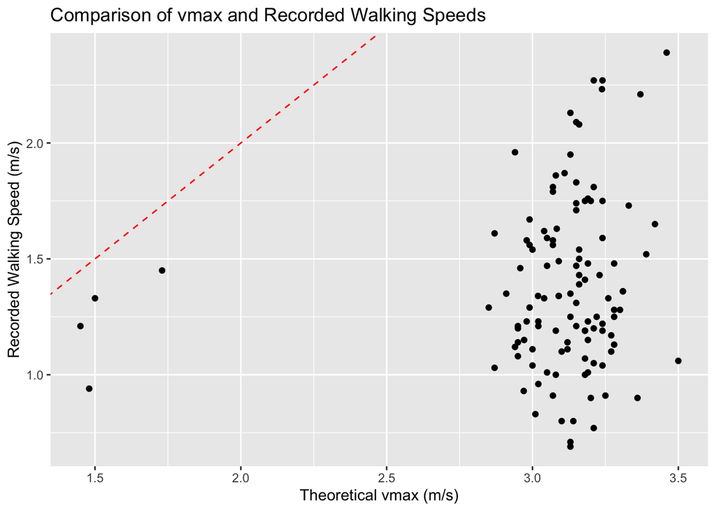

```r
# Compare vmax to recorded walking speeds
ggplot(class_data, aes(x = vmax.in.ms..1., y = recorded.walking.in.ms..1.)) +
  geom_point() +
  geom_abline(slope = 1, intercept = 0, color = "red", linetype = "dashed") +
  labs(title = "Comparison of vmax and Recorded Walking Speeds",
       x = "Theoretical vmax (m/s)", y = "Recorded Walking Speed (m/s)")
```

## Patterns Revealed by Calculating the Froude Number:

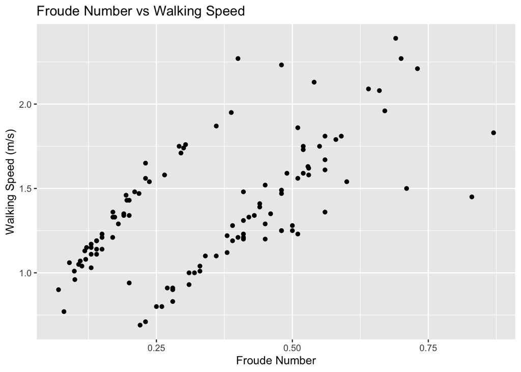

```r
# Plot Froude number against walking speed
ggplot(class_data, aes(x = Froude.number, y = recorded.walking.in.ms..1.),) +
  geom_point() +
  labs(title = "Froude Number vs Walking Speed",
       x = "Froude Number", y = "Walking Speed (m/s)")
```

## Variation of Actual Pendulum Walking Speed with Human Length and Sex

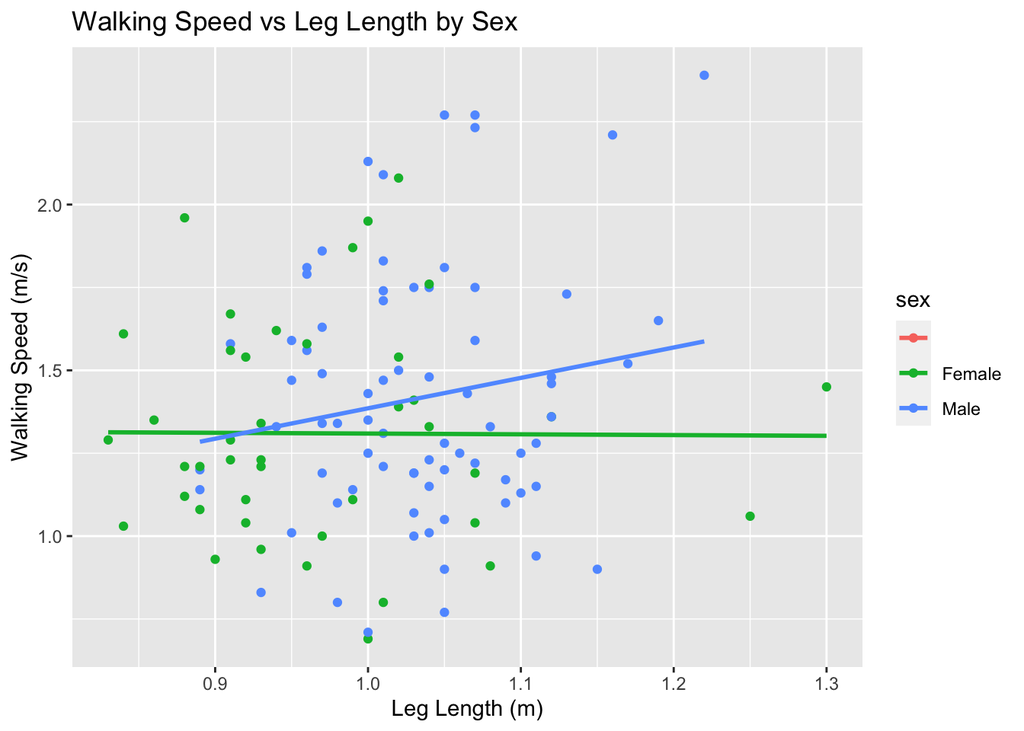

```r
# Plot walking speed against leg length colored by sex with a best fit line
ggplot(class_data, aes(x = leg.length.in.m, y = recorded.walking.in.ms..1., color = sex)) +
  geom_point() +
  geom_smooth(method = "lm", se = FALSE) +
  labs(title = "Walking Speed vs Leg Length by Sex",
       x = "Leg Length (m)", y = "Walking Speed (m/s)")
```

## Variation of Actual Pendulum Walking Speed with Human Size and Sex

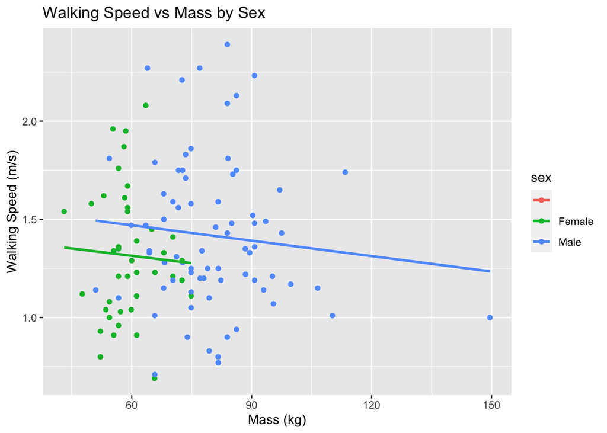

```r
# Plot walking speed against leg length colored by sex with a best fit line
ggplot(class_data, aes(x = Mass.in.Kg, y = recorded.walking.in.ms..1., color = sex)) +
  geom_point() +
  geom_smooth(method = "lm", se = FALSE) +
  labs(title = "Walking Speed vs Mass by Sex",
       x = "Mass (kg)", y = "Walking Speed (m/s)")
```

## Changes in Pelvic Tilt with Increased Walking Speeds

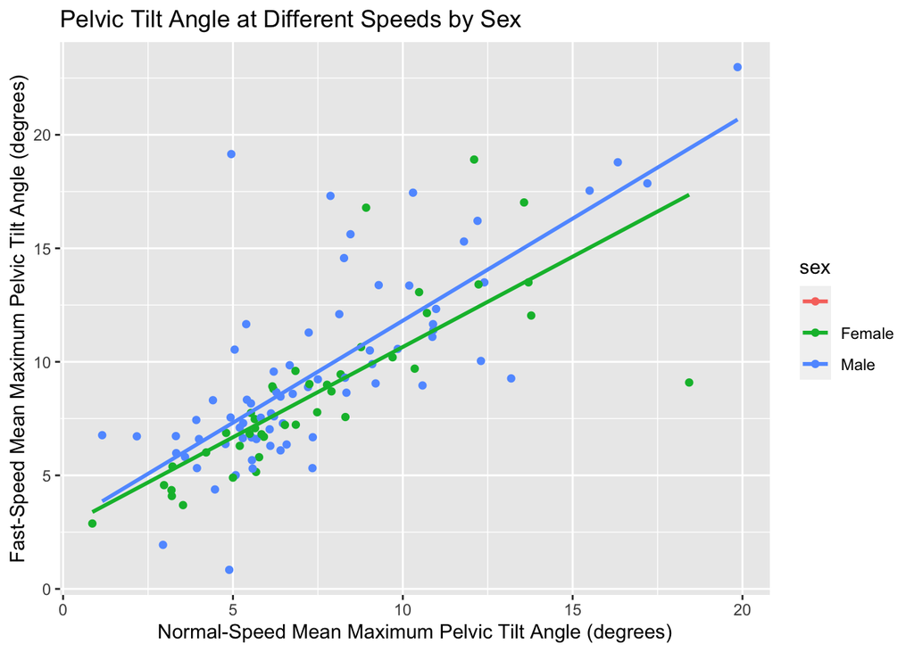

```r
ggplot(class_data, aes(x = normal.speed.mean.maximum.pelvic.tilt.angle, y = fast.speed.mean.maximum.pelvic.tilt.angle, color = sex)) +
  geom_point() +
  geom_smooth(method = "lm", se = FALSE) +
  labs(title = "Pelvic Tilt Angle at Different Speeds by Sex",
       x = "Normal-Speed Mean Maximum Pelvic Tilt Angle (degrees)",
       y = "Fast-Speed Mean Maximum Pelvic Tilt Angle (degrees)")
```

## Variation of Pelvic Tilt at Normal Walking Speeds with Human Size and Sex:

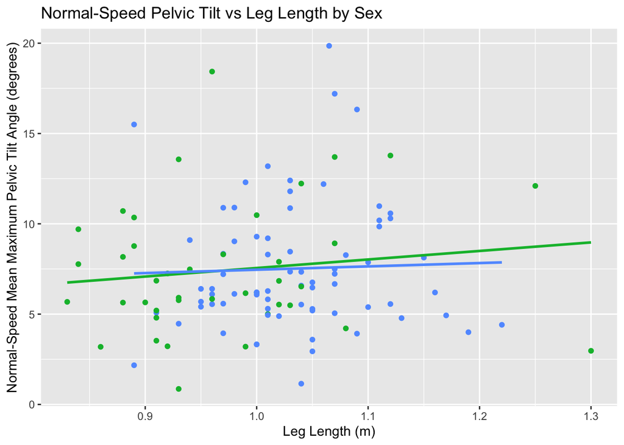

```r
# Create the first plot for normal walking speed vs. leg length
ggplot(class_data, aes(x = leg.length.in.m, y = normal.speed.mean.maximum.pelvic.tilt.angle, color = sex)) +
  geom_point() +
  geom_smooth(method = "lm", se = FALSE) +
  labs(title = "Normal-Speed Pelvic Tilt vs Leg Length by Sex",
       x = "Leg Length (m)", y = "Normal-Speed Mean Maximum Pelvic Tilt Angle (degrees)") +
  theme(legend.position="none") # Hide legend to avoid duplication
```

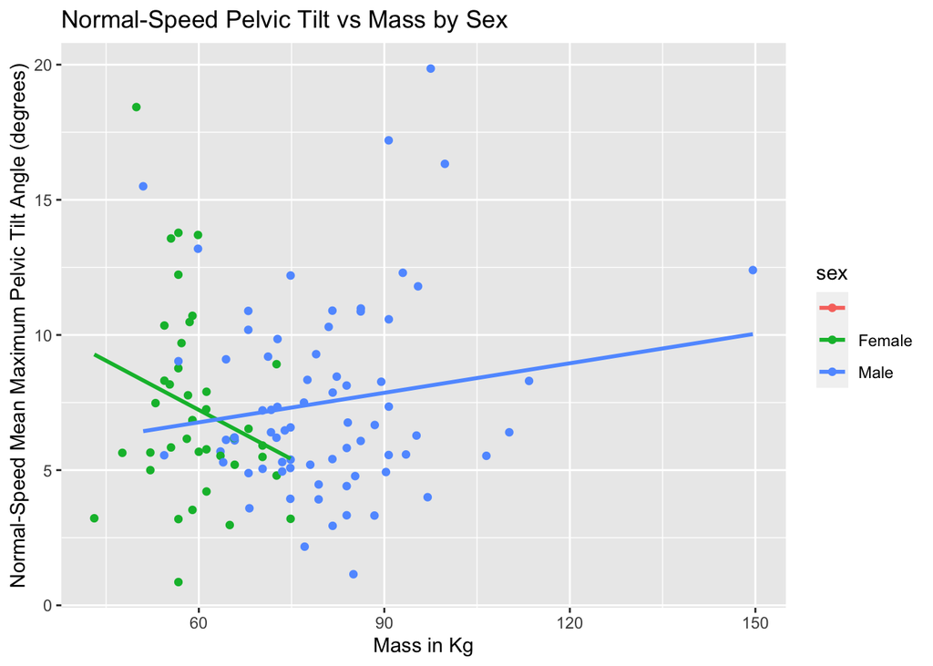

```r
# Create the second plot for normal walking speed vs. mass in Kg
ggplot(class_data, aes(x = Mass.in.Kg, y = normal.speed.mean.maximum.pelvic.tilt.angle, color = sex)) +
  geom_point() +
  geom_smooth(method = "lm", se = FALSE) +
  labs(title = "Normal-Speed Pelvic Tilt vs Mass by Sex",
       x = "Mass in Kg", y = "Normal-Speed Mean Maximum Pelvic Tilt Angle (degrees)")
```

# Interpretations

**Comparison of Theoretical and Actual Walking Speeds**:

- The observed actual walking speeds were consistently slower than the theoretical vmax predicted by the inverted pendulum model. This aligns with Usherwood’s (2005) discussion on the limitations of walking speed due to biomechanical constraints, such as the simplifications of the model which do not account for the dynamic motion of body parts beyond the legs (Usherwood 2005). The Froude number, a dimensionless number representing the ratio of centripetal force to gravitational force in the inverted pendulum model, further substantiates that walking efficiencies in practice are lower than theoretical maximums, potentially due to energy conservation strategies that humans have evolved for walking.

**Variation of Actual Pendulum Walking Speed with Human Size and Sex**:

**Changes in Pelvic Tilt with Increased Walking Speeds**:

**Variation of Pelvic Tilt at Normal Walking Speeds with Human Size and Sex**:

- The data demonstrates a difference in pelvic tilt with body mass that is distinct between sexes. In males, a positive correlation between body mass and pelvic tilt suggests a biomechanical adjustment to accommodate increased load, as discussed by Usherwood (2005), who highlights that different body sizes and shapes necessitate different walking strategies (Usherwood 2005). In females, however, an increase in body mass correlates with a decrease in pelvic tilt, possibly indicating a different biomechanical strategy to distribute the load more efficiently during walking.

# Author Contributions

- Jonah: Wrote the code & graphed the data
- Emma: Used MTrackJ to track the data and produce the txt files
- Marc: Analyzed the figures and wrote the interpretations

# References

Usherwood, James Richard. 2005. “Why Not Walk Faster?” *Biology Letters* 1 (3): 338–41.